# Stack overflow 2018 survey analysis

Joan Claverol Romero - Data analytics mentor at Ubiqum Code Academy

# 1 Report purpose

The goal of this report is to analyise the stack overflow survey made in 2018, here is the [link](https://www.kaggle.com/stackoverflow/stack-overflow-2018-developer-survey) to the data. We will put the focus on developers working as data analysts and data scientists. The main questions to answer would be:

1. How much do they earn? We will only analyse the ones living in European countries like Germany, Spain or France.
2. Which are the technologies they use? Detect the used and desired languages, databases and frameworks.

First of all, we will define the profile we are interested on:

- Not a student and not coding as a hobby
- Age between “25 - 34 years old” or “35 - 44 years old”
- Type of developer: Data or business analyst, Data scientist or machine learning specialist, Marketing or sales professional.

# 2 General analysis

After filtering our the data, we have 33368 respondents, in relation to the 98855 we have before.

Let’s see in where the respondents come from:

[interactive chart not shown]

## 2.1 European salaries

Now, let’s find out which is the country where you can earn more money:

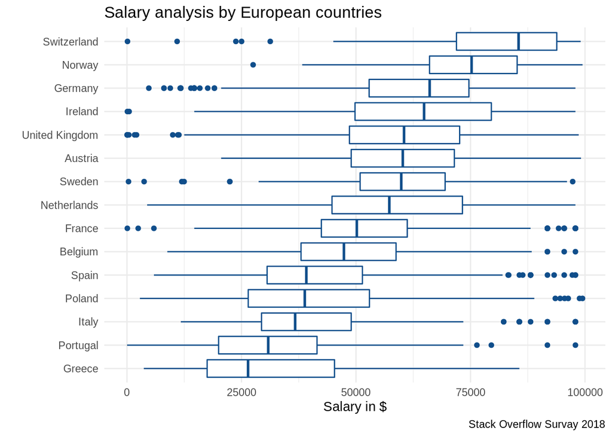

# 3 Actual and future technologies

## 3.1 Operating system

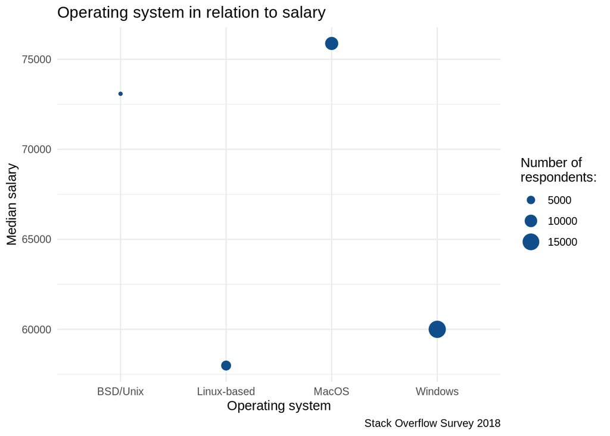

## 3.2 Communication tools

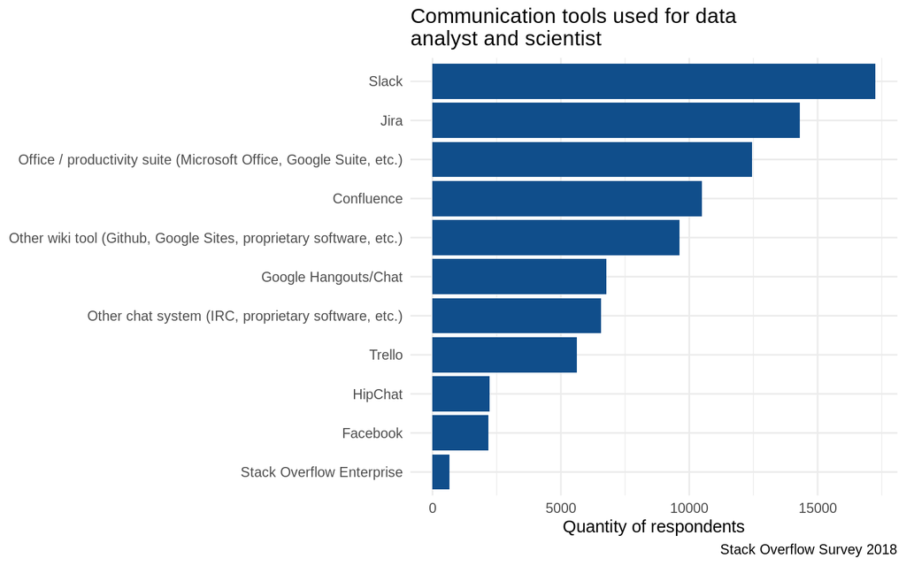

## 3.3 Language analysis

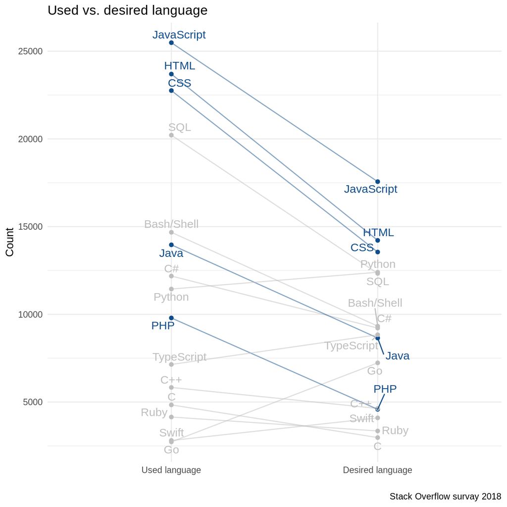

## 3.4 Framework analysis

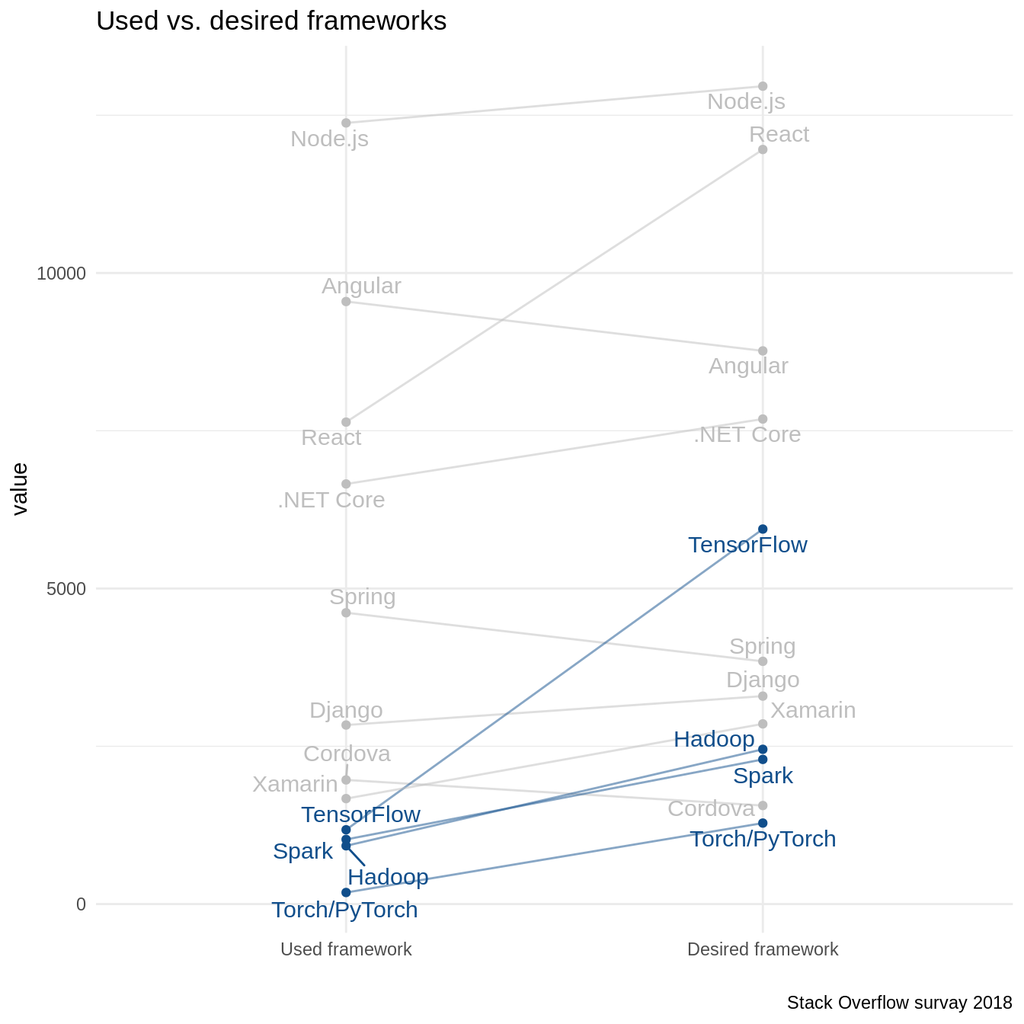

## 3.5 Database technologies

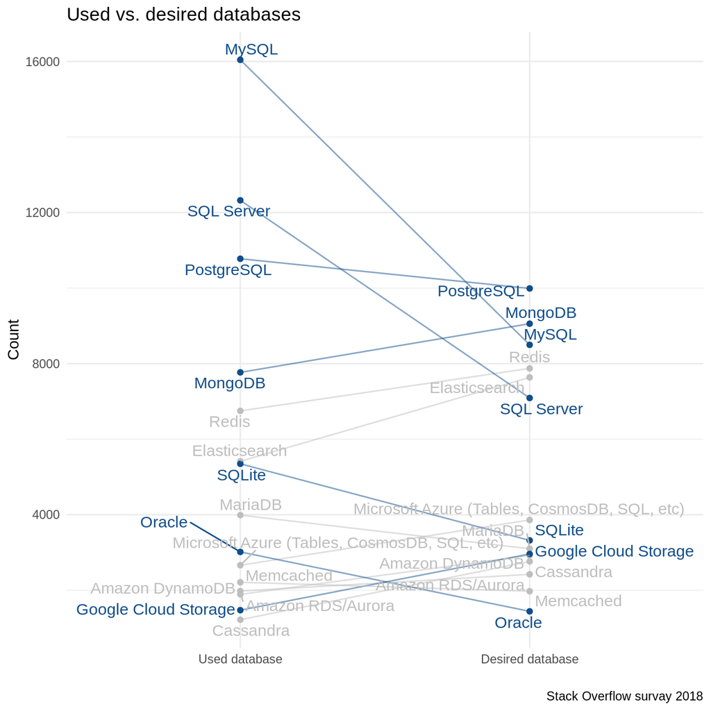